# Midterm_BANA7038001_DATA ANALY METH

#### Re-modeling by removing insignificant variables one at a time.

##### Goal: Rep1 :In repetative process,remove insignificant variables one by one.Remove no. of passenger

```
##
## Call:
## lm(formula = distance ~ (duration + speed_air + height + pitch +
##     aircraft_make), data = refinedDataSet)
##
## Residuals:
##     Min      1Q  Median      3Q     Max
## -619.76 -198.50  -75.19  114.73 1317.24
##
## Coefficients:
##                 Estimate Std. Error t value Pr(>|t|)
## (Intercept)   -3127.6304   119.3589 -26.204   <2e-16 ***
## duration         -0.2001     0.2325  -0.861    0.390
## speed_air        48.7088     0.6694  72.766   <2e-16 ***
## height           13.8435     1.1541  11.995   <2e-16 ***
## pitch            17.2914    23.0842   0.749    0.454
## aircraft_make   443.0522    24.0738  18.404   <2e-16 ***
## ---
## Signif. codes:  0 '***' 0.001 '**' 0.01 '*' 0.05 '.' 0.1 ' ' 1
##
## Residual standard error: 313.3 on 775 degrees of freedom
## Multiple R-squared:  0.8808, Adjusted R-squared:  0.8801
## F-statistic:  1146 on 5 and 775 DF,  p-value: < 2.2e-16
```

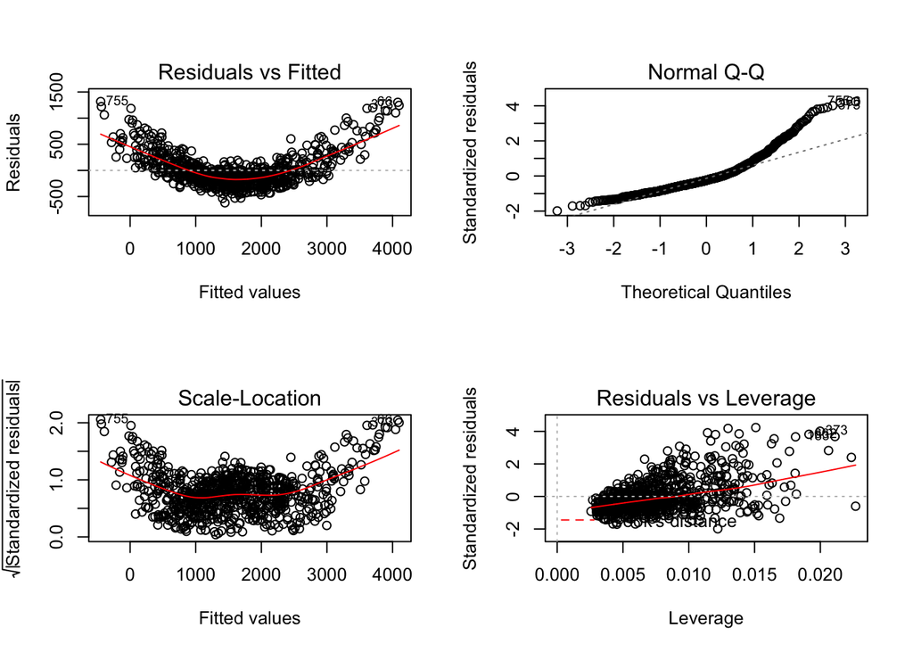

##### Observations:

Even we remove no_pasg variable and speed_ground, there is no much improvement in residuals plots.Still there is non-linear relationship between residuals and fitted values. QQ plot is not distributed properly.

##### Rep2:In repetative process,remove insignificant variables one by one.Remove duration

```
##
## Call:
## lm(formula = distance ~ (speed_air + height + pitch + aircraft_make),
##     data = refinedDataSet)
##
## Residuals:
##     Min      1Q  Median      3Q     Max
## -624.93 -199.78  -75.12  118.20 1323.51
##
## Coefficients:
##                 Estimate Std. Error t value Pr(>|t|)
## (Intercept)   -3163.0477   112.0226 -28.236   <2e-16 ***
## speed_air        48.7294     0.6688  72.856   <2e-16 ***
## height           13.8332     1.1539  11.988   <2e-16 ***
## pitch            17.9790    23.0665   0.779    0.436
## aircraft_make   443.6616    24.0594  18.440   <2e-16 ***
## ---
## Signif. codes:  0 '***' 0.001 '**' 0.01 '*' 0.05 '.' 0.1 ' ' 1
##
## Residual standard error: 313.2 on 776 degrees of freedom
## Multiple R-squared:  0.8807, Adjusted R-squared:  0.8801
## F-statistic:  1432 on 4 and 776 DF,  p-value: < 2.2e-16
```

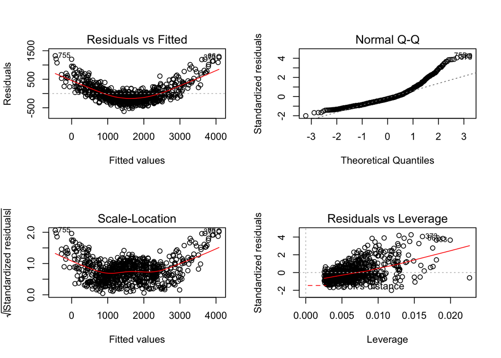